# 第四讲课堂笔记

定量数据分析

# 引言

- 上节课，我们检查并描述了数据。
- 今天，我们将在此基础上进一步学习如何将数据可视化。
- 数据可视化是任何分析过程中至关重要的一步。
- 至少，它有助于我们理解数据并发现规律。
- 有时，一幅制作精良的可视化图表就足以清楚说明问题。
- 这时可能不需要进一步分析。

# 图形语法

- 理解统计图形的一个实用思路是威尔金森提出的“图形语法”。
- 它提供了一套规则，帮助我们理解和构建图形。
- 这一语法包含若干组成部分，是各种统计图形的基础。

# 图形语法的组成部分

- 数据以及一组映射关系，用于说明如何将变量映射到可感知的视觉属性。
- 图形中出现的几何对象，例如点、线和多边形。
- 统计变换，可用于变换数据或对数据进行汇总。
- 刻度：将数据空间中的数值映射到视觉属性空间中的值，例如形状、颜色和大小。
- 坐标系统：决定数据坐标如何映射到图形平面。
- 分面：把数据拆分为不同子集，分别作图。

# R语言中的图形

- R语言具有多种绘图系统。
- 部分属于基础R，另一些由lattice等扩展包引入。
- 如今，ggplot2事实上已成为R语言绘图的通用标准，也是R语言最大的优势之一。
- 它也是tidyverse的一部分，因此与我们采用的数据处理方式能够很好地配合。
- 名称中的gg代表“图形语法”（grammar of graphics）。
- 这种方法通过逐层叠加，让我们能够构建几乎任何类型的统计图形。
- 本讲将参考Hadley Wickham的《ggplot2：优雅的数据分析图形》。

# 能做到不代表就应该这样做

- 就像语言一样，一个句子可以语法正确，却毫无意义。
- 考虑下面这个句子：

> 愤怒的石头像逗号一样吠叫。
- 这个句子在语法上正确，但并没有实际意义。
- ggplot2的方法旨在让你能够构建想要的各种图形。
- 始终要思考自己试图展示什么，以及展示方式是否合理。
- 图形语法本身不会替我们精细调整外观，但值得花时间做好这些细节。

# ggplot2

- 必须先加载ggplot2；不过，如果使用library(tidyverse)，它也会随tidyverse一起加载。
- 编写绘图代码有好几种方式。
- 我们选用一种常见的方法（也是我自己使用的方法）。
- 图形通过不断添加元素来构建。
- 我们从调用ggplot()函数开始创建图形。
- 注意：函数名是ggplot，而软件包名是ggplot2。
- 此时并非一定要指定参数，但我建议指定。

# ggplot函数的参数

- 第一个参数是将要使用的数据。
- 数据可以通过管道传入，也可以直接写在函数中。
- 我更喜欢通过管道传入数据。
- 在ggplot函数中，可以使用aes函数指定美学映射（视觉属性映射）。
- 我们从x变量开始，它显示在横轴上。
- 也可以指定y变量，它显示在纵轴上。
- 还可以指定其他映射，不过暂时先不讨论。

# 添加几何图层

- 指定数据和视觉映射后，就可以选择绘图使用的几何对象。
- 具体使用哪一种，取决于我们想展示什么。
- 今天我们将探索几种类型。

# 我们的因变量

- 一个很好的起点是查看我们的因变量。
- 仅使用一个变量时，能制作的图形类型相对有限。
- 我们将先学习两个重要示例：直方图和密度图。
- 它们都可以帮助我们检查变量的分布。
- 分布本身就值得研究；之后我们还会看到它对其他分析也很重要。

# 直方图

- 直方图将连续变量划分成若干离散的区间（组）。
- 统计每个区间内的观测数量。
- 用柱形表示每个区间内的观测数量。
- 我们可以自行选择组距，虽然多数软件也会提供默认设置。
- 我们打算用柱形来展示数据，但通常必须先将数据按区间聚合。
- 由于直方图非常重要，ggplot提供了一个快捷方法。
- 可以通过使用直方图几何图层来实现。
- 这样就会自动完成分组统计和图形展示。

# 小时工资的分布

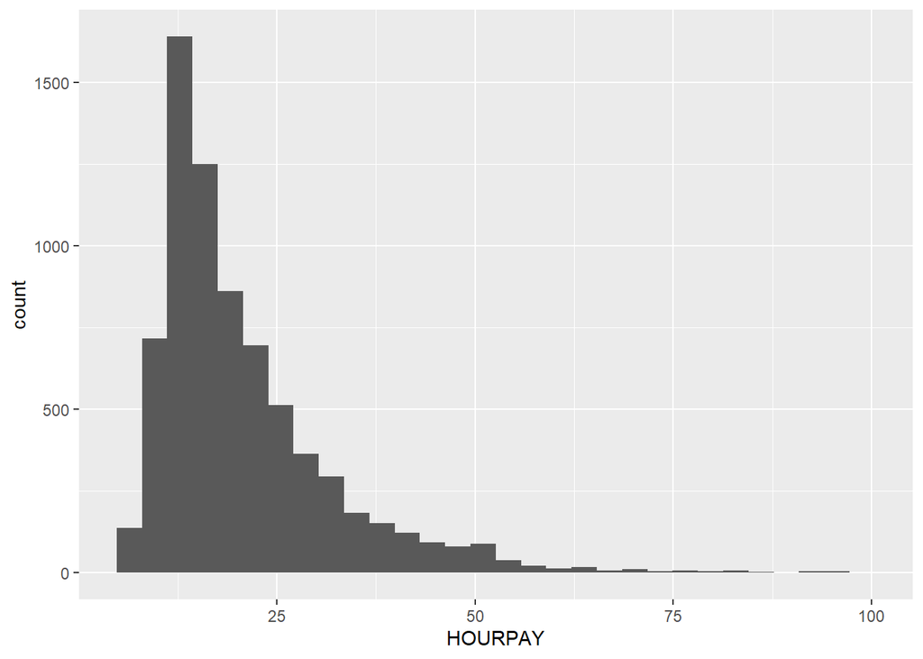

```r
lfs %>% ggplot(aes(HOURPAY)) + geom_histogram()
```

# 我们能从直方图中看出什么？

- 首先可以看出，这个分布呈右偏（正偏）状态。
- 大多数观测集中在较低数值一端，而极少数高收入者出现在最右侧。
- 我们可以通过多种方式改善图表外观。
- 尤其值得注意的是，受数据分布影响，图形中有很大面积是空白的。
- 在解决这个问题前，先学习几种改善图表的方法。

# 标签

- 呈现给他人的每一幅图都必须有恰当的标签。
- 不要直接使用原始变量名，尤其当变量名本身不够清晰时。
- 图表有多种添加标签的方法。
- 我建议在图中加入labs函数。
- 通过这个函数，可以指定要添加标签的图形元素。

# labs函数的部分参数

- title：放在图表上方的标题。
- subtitle：放在主标题下方的副标题。
- x：横轴标签。
- y：纵轴标签。
- caption：出现在图形右下方的说明文字，可以写明数据来源等信息。

# 为直方图添加标签

```r
lfs %>% ggplot(aes(HOURPAY)) +
  geom_histogram() +
  labs( title = "Distribution of hourly wage",
        x = "Hourly wage (£)",
        y = "Count",
        caption = "Source: Quarterly Labour Force Survey - January-March 2025")
```

# 添加标签后的直方图

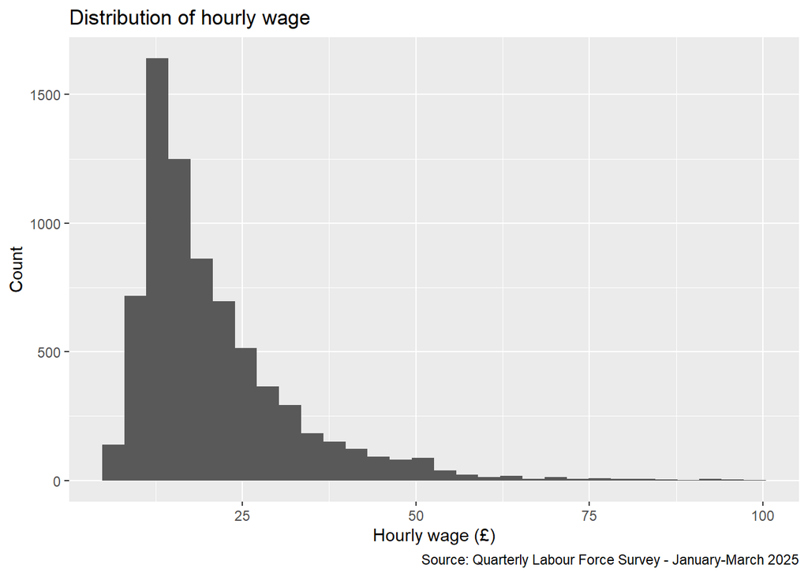

# 组距为10英镑

```r
lfs %>% ggplot(aes(HOURPAY)) +
  geom_histogram(binwidth = 10) +
  labs( title = "Distribution of hourly wage",
        x = "Hourly wage (£)",
        y = "Count",
        caption = "Source: Quarterly Labour Force Survey - January-March 2025")
```

# 组距为10英镑

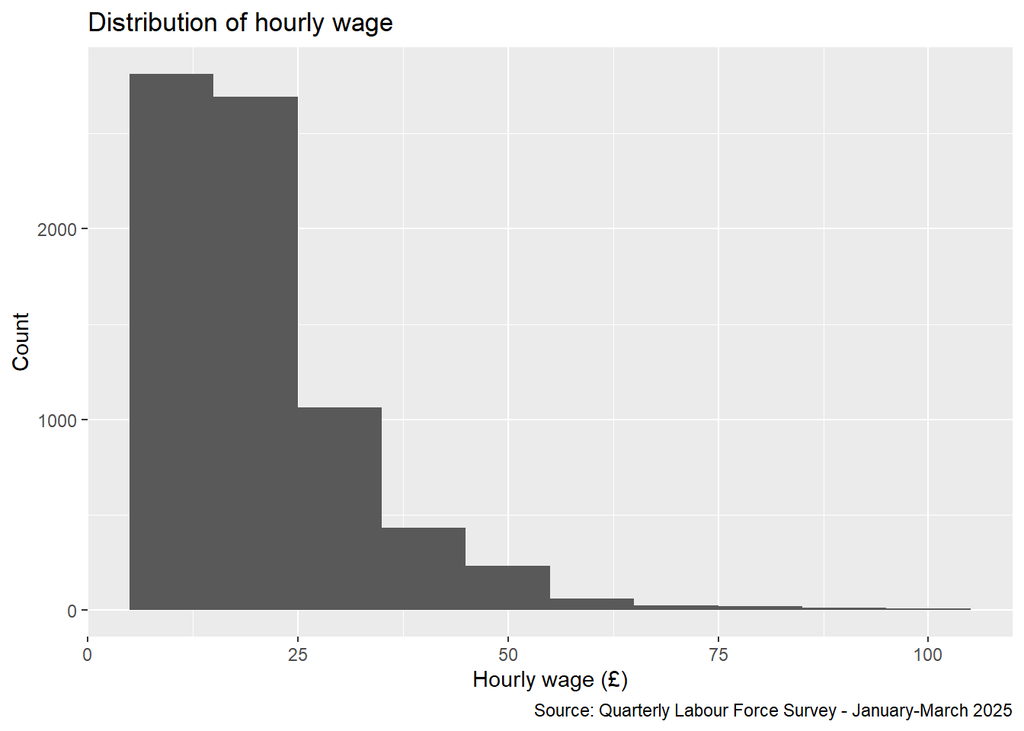

# 组距为20英镑

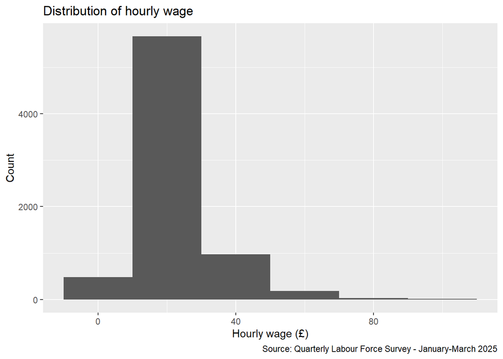

# 组距为30英镑

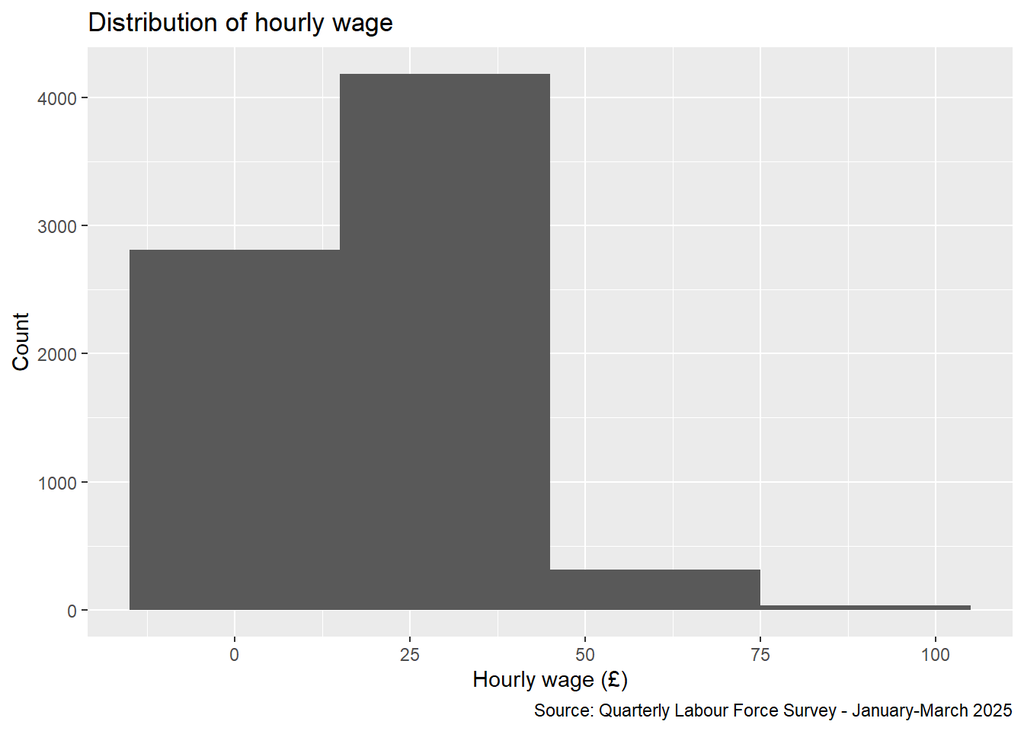

# 其他选项

- 几乎可以自定义图形外观的任何部分。
- 还可以选择一个绘图主题，利用别人已经完成的部分设计。
- 例如，可以选择theme_dark()、theme_bw()或theme_void()。
- 也可以查看ggthemes扩展包，获得更多选择。
- 还有其他提供各种主题的扩展包。（原讲义此处还提到了“添加主题”。）

```r
lfs %>% ggplot(aes(HOURPAY)) +
  geom_histogram() +
  labs( title = "Distribution of hourly wage",
        x = "Hourly wage (£)",
        y = "Count",
        caption = "Source: Quarterly Labour Force Survey - January-March 2025") +
  theme_dark()
```

[output not shown]